# EasyVisa Project

### Let's try using logistic regression as the base estimator for bagging classifier:

- Now, let's try and change the base_estimator of the bagging classifier, which is a decision tree by default.
- We will pass the logistic regression as the base estimator for bagging classifier.

```python
bagging_lr=BaggingClassifier(base_estimator=LogisticRegression(solver='newton-cg',random_state=1,max_iter=1000),random_state=1)
bagging_lr.fit(X_train,y_train)
```

```
BaggingClassifier(base_estimator=LogisticRegression(max_iter=1000,
                                                    random_state=1,
                                                    solver='newton-cg'),
                  random_state=1)
```

```python
#Using above defined function to get accuracy, recall and precision on train and test set
bagging_lr_score=get_metrics_score(bagging_lr)
```

```
Accuracy on training set :  0.7375532630634671
Accuracy on test set :  0.7401883830455259
Recall on training set :  0.8786752281176073
Recall on test set :  0.8780393670397529
Precision on training set :  0.7621839501648956
Precision on test set :  0.7706639566395664
```

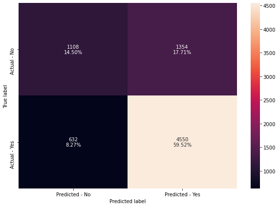

```python
make_confusion_matrix(bagging_lr,y_test)
```

- Observations
- The accuracy in training and test datasets are closely matching after the tuning. Training is at 73% whereas test is at 74%.
- Insights
- Bagging classifier with logistic regression as base_estimator is not overfitting the data

```python
# Choose the type of classifier.
rf_estimator_tuned = RandomForestClassifier(random_state=1,class_weight="balanced")

# Grid of parameters to choose from
## add from article
# parameters = {"n_estimators": [110],
#     "min_samples_leaf": [5],
#     "max_features": [5,10,15,20],
#     "max_samples": np.arange(0.3, 0.7, 0.1),
#              }

parameters = {
    "n_estimators": [100,110,120],
    "min_samples_leaf": [5],
    "max_features": [5,10,15,20],
    "max_samples": np.arange(0.3, 0.7, 0.1),
            }

# Type of scoring used to compare parameter combinations
acc_scorer = metrics.make_scorer(metrics.accuracy_score)

# Run the grid search
grid_obj = GridSearchCV(rf_estimator_tuned, parameters, scoring=acc_scorer,cv=5)
grid_obj = grid_obj.fit(X_train, y_train)

# Set the clf to the best combination of parameters
rf_estimator_tuned = grid_obj.best_estimator_

# Fit the best algorithm to the data.
rf_estimator_tuned.fit(X_train, y_train)
```

```
RandomForestClassifier(class_weight='balanced', max_features=15,
                       max_samples=0.3, min_samples_leaf=5, n_estimators=120,
                       random_state=1)
```

```python
#Using above defined function to get accuracy, recall and precision on train and test set
rf_estimator_tuned_score=get_metrics_score(rf_estimator_tuned)
```

```
Accuracy on training set :  0.7945167077820139
Accuracy on test set :  0.738880167451596
Recall on training set :  0.843528218992903
Recall on test set :  0.8091470474720185
Precision on training set :  0.8463168602186997
Precision on test set :  0.8063461538461538
```

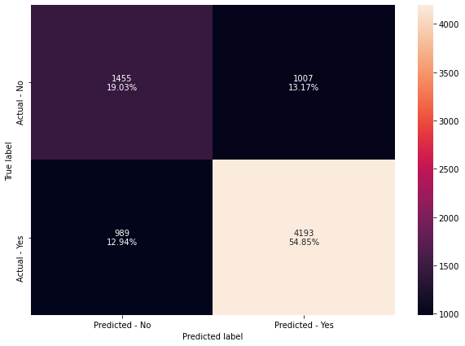

```python
make_confusion_matrix(rf_estimator_tuned,y_test)
```

- Insights
- We can see that random forest's performance has increased as compared to the random forest model with default parameters.
- Model is slightly overfitting the data but the accuarcy with testing and training is much better

### Let's try using class_weights for random forest:

```python
# Choose the type of classifier.
rf_estimator_weighted = RandomForestClassifier(random_state=1)

# Grid of parameters to choose from
## add from article
parameters = {
    "class_weight": [{0: 0.6, 1: 0.4}],
    "n_estimators": [100,110,120],
    "min_samples_leaf": [5],
    "max_features": [5,10,15,20],
    "max_samples": np.arange(0.3, 0.7, 0.1),

}

# Type of scoring used to compare parameter combinations
acc_scorer = metrics.make_scorer(metrics.recall_score)

# Run the grid search
grid_obj = GridSearchCV(rf_estimator_weighted, parameters, scoring=acc_scorer,cv=5)
grid_obj = grid_obj.fit(X_train, y_train)

# Set the clf to the best combination of parameters
rf_estimator_weighted = grid_obj.best_estimator_

# Fit the best algorithm to the data.
rf_estimator_weighted.fit(X_train, y_train)
```

```
RandomForestClassifier(class_weight={0: 0.6, 1: 0.4}, max_features=15,
                       max_samples=0.3, min_samples_leaf=5, n_estimators=120,
                       random_state=1)
```

```python
#Using above defined function to get accuracy, recall and precision on train and test set
rf_estimator_weighted_score=get_metrics_score(rf_estimator_weighted)
```

```
Accuracy on training set :  0.7904238618524333
Accuracy on test set :  0.7462061747776033
Recall on training set :  0.866846907739101
Recall on test set :  0.8367425704361251
Precision on training set :  0.8259539526646272
Precision on test set :  0.7985267034990792
```

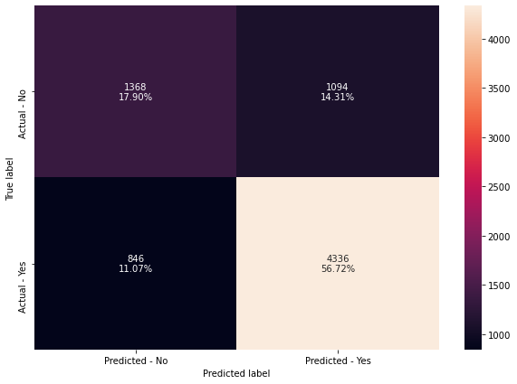

```python
make_confusion_matrix(rf_estimator_weighted,y_test)
```

### Checking the feature importance

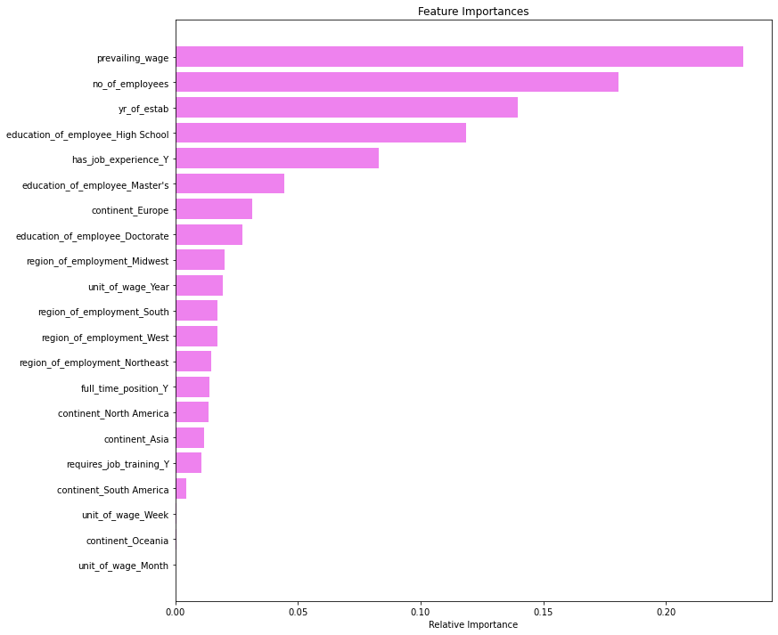

```python
importances = rf_estimator_weighted.feature_importances_
indices = np.argsort(importances)
feature_names = list(X.columns)

plt.figure(figsize=(12,12))
plt.title('Feature Importances')
plt.barh(range(len(indices)), importances[indices], color='violet', align='center')
plt.yticks(range(len(indices)), [feature_names[i] for i in indices])
plt.xlabel('Relative Importance')
plt.show()
```

- Prevailing wage,number of employees and year of establishment are the top 3 important features

### Boosting - Hyperparameter Tuning

#### AdaBoost Classifier

```python
# Choose the type of classifier.
abc_tuned = AdaBoostClassifier(random_state=1)

# Grid of parameters to choose from
## add from article
parameters = {
    #Let's try different max_depth for base_estimator
    "base_estimator":[DecisionTreeClassifier(max_depth=1, random_state=1),DecisionTreeClassifier(max_depth=2, random_state=1),DecisionTreeClassifier(max_depth=3, random_state=1),DecisionTreeClassifier(max_depth=4, random_state=1),DecisionTreeClassifier(max_depth=4, random_state=1)],
    "n_estimators": np.arange(10,60,10),
    "learning_rate":np.arange(0.1,2,0.5)
}

# Type of scoring used to compare parameter combinations
acc_scorer = metrics.make_scorer(metrics.accuracy_score)

# Run the grid search
grid_obj = GridSearchCV(abc_tuned, parameters, scoring=acc_scorer,cv=5)
grid_obj = grid_obj.fit(X_train, y_train)

# Set the clf to the best combination of parameters
abc_tuned = grid_obj.best_estimator_

# Fit the best algorithm to the data.
abc_tuned.fit(X_train, y_train)
```

```
AdaBoostClassifier(base_estimator=DecisionTreeClassifier(max_depth=4,
                                                         random_state=1),
                   learning_rate=0.1, random_state=1)
```

```python
#Using above defined function to get accuracy, recall and precision on train and test set
abc_tuned_score=get_metrics_score(abc_tuned)
```

```
Accuracy on training set :  0.7583538910069523
Accuracy on test set :  0.750654107796965
Recall on training set :  0.8737749239607976
Recall on test set :  0.8641451177151679
Precision on training set :  0.7859857121143031
Precision on test set :  0.7883802816901408
```

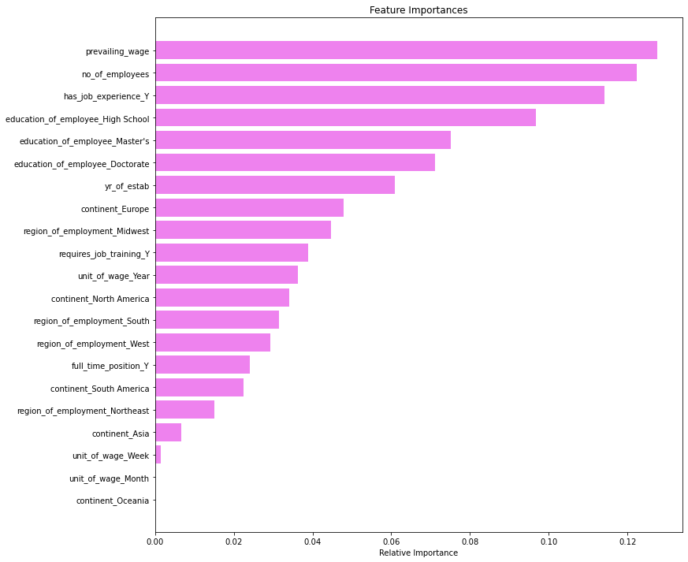

```python
importances = abc_tuned.feature_importances_
indices = np.argsort(importances)
feature_names = list(X.columns)

plt.figure(figsize=(12,12))
plt.title('Feature Importances')
plt.barh(range(len(indices)), importances[indices], color='violet', align='center')
plt.yticks(range(len(indices)), [feature_names[i] for i in indices])
plt.xlabel('Relative Importance')
plt.show()
```

- Insights
- Based off the tuned AdaBoost classifier,the influencing factors for visa certifications are prevailing wage,number of employees and having job experience

#### Gradient Boosting Classifier

```python
gbc_init = GradientBoostingClassifier(init=AdaBoostClassifier(random_state=1),random_state=1)
gbc_init.fit(X_train,y_train)
```

```
GradientBoostingClassifier(init=AdaBoostClassifier(random_state=1),
                           random_state=1)
```

```python
#Using above defined function to get accuracy, recall and precision on train and test set
gbc_init_score=get_metrics_score(gbc_init)
```

```
Accuracy on training set :  0.7560551693204755
Accuracy on test set :  0.7511773940345369
Recall on training set :  0.8774923960797567
Recall on test set :  0.8695484368969509
Precision on training set :  0.7816662903589975
Precision on test set :  0.7861130495464062
```

```python
# Choose the type of classifier.
gbc_tuned = GradientBoostingClassifier(init=AdaBoostClassifier(random_state=1),random_state=1)

# Grid of parameters to choose from
# "n_estimators": [100,110,120],
# "n_estimators": np.arange(10,80,10),
# "n_estimators": np.arange(100,500,50),
# "n_estimators": np.arange(100,600,100),
#     "max_depth":np.arange(5,8,1),
#     "max_depth":[np.arange(5,8,1)],
## add from article
# Notes - Here the tuning precedence has been to change the max depth
# followed by min_samples_split,max_features and subsample
parameters = {
    "n_estimators": [100,500,700,900],
    "subsample":[0.8],
    "max_features":[0.8],
    "max_depth":[10],
    "min_samples_split":[8000],
}

# Type of scoring used to compare parameter combinations
acc_scorer = metrics.make_scorer(metrics.accuracy_score)

# Run the grid search
grid_obj = GridSearchCV(gbc_tuned, parameters, scoring=acc_scorer,cv=5)
grid_obj = grid_obj.fit(X_train, y_train)

# Set the clf to the best combination of parameters
gbc_tuned = grid_obj.best_estimator_

# Fit the best algorithm to the data.
gbc_tuned.fit(X_train, y_train)
```

```
GradientBoostingClassifier(init=AdaBoostClassifier(random_state=1),
                           max_depth=10, max_features=0.8,
                           min_samples_split=8000, random_state=1,
                           subsample=0.8)
```

```python
#Using above defined function to get accuracy, recall and precision on train and test set
gbc_tuned_score=get_metrics_score(gbc_tuned)
```

```
Accuracy on training set :  0.7467481498093743
Accuracy on test set :  0.7479068550497122
Recall on training set :  0.8658330517066577
Recall on test set :  0.8627942879197221
Precision on training set :  0.7777187523715565
Precision on test set :  0.7861790047476701
```

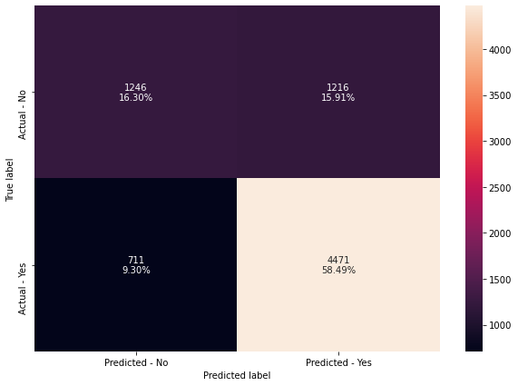

```python
make_confusion_matrix(gbc_tuned,y_test)
```

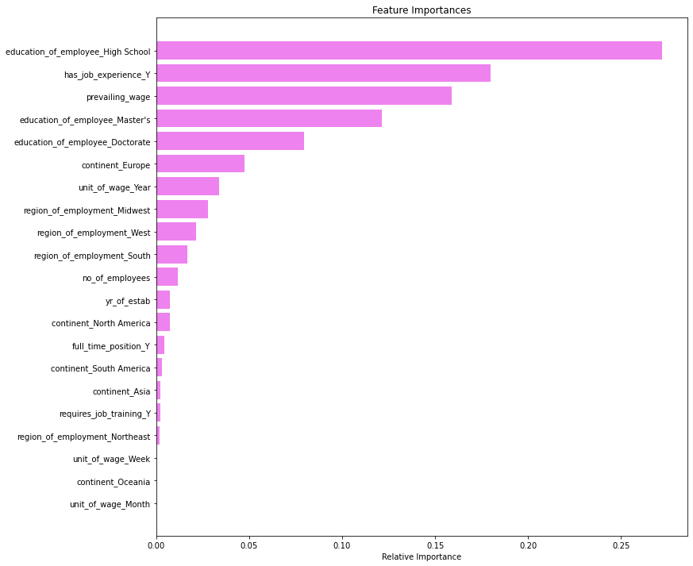

```python
importances = gbc_tuned.feature_importances_
indices = np.argsort(importances)
feature_names = list(X.columns)

plt.figure(figsize=(12,12))
plt.title('Feature Importances')
plt.barh(range(len(indices)), importances[indices], color='violet', align='center')
plt.yticks(range(len(indices)), [feature_names[i] for i in indices])
plt.xlabel('Relative Importance')
plt.show()
```

- Insights
- The top 3 influencing factors as per the hyper tuned gradient boosting are high school education,job experience and prevailing wage

#### XGBoost Classifier

```python
# Choose the type of classifier.
xgb_tuned = XGBClassifier(random_state=1,eval_metric='logloss')

# Grid of parameters to choose from
#     1st iteration
#     "n_estimators": np.arange(100,1000,200),
#     "subsample":[0.5,0.7,0.9,1],
## add from
# Notes - First tuned the max_depth & min_child_weight
# After this tuned the gamma followed by subsample and then colsample_bylevel
# Finally reduced the learning rate
parameters = {
    "n_estimators": [110],
    "scale_pos_weight":[1],
    "subsample":np.arange(0.8,1,1),
#    "subsample":[0.8],
     "learning_rate":[0.01],
#     "learning_rate":[0.1],
    "gamma":np.arange(0,5,2),
#     "colsample_bytree":np.arange(6,10,1),
#     "colsample_bytree":[0.8],
     "colsample_bylevel":np.arange(0.8,1,1),
    "max_depth":np.arange(5,10,2),
    "min_child_weight":np.arange(6,8,1),
#     "max_depth":[5],
#     "min_child_weight":[6],
}

# Type of scoring used to compare parameter combinations
acc_scorer = metrics.make_scorer(metrics.accuracy_score)

# Run the grid search
grid_obj = GridSearchCV(xgb_tuned, parameters,scoring=acc_scorer,cv=5)
grid_obj = grid_obj.fit(X_train, y_train)

# Set the clf to the best combination of parameters
xgb_tuned = grid_obj.best_estimator_

# Fit the best algorithm to the data.
xgb_tuned.fit(X_train, y_train)
```

```
XGBClassifier(base_score=0.5, booster='gbtree', colsample_bylevel=0.8,
              colsample_bynode=1, colsample_bytree=1, eval_metric='logloss',
              gamma=4, gpu_id=-1, importance_type='gain',
              interaction_constraints='', learning_rate=0.01, max_delta_step=0,
              max_depth=9, min_child_weight=7, missing=nan,
              monotone_constraints='()', n_estimators=110, n_jobs=8,
              num_parallel_tree=1, random_state=1, reg_alpha=0, reg_lambda=1,
              scale_pos_weight=1, subsample=0.8, tree_method='exact',
              validate_parameters=1, verbosity=None)
```

```python
#Using above defined function to get accuracy, recall and precision on train and test set
xgb_tuned_score=get_metrics_score(xgb_tuned)
```

```
Accuracy on training set :  0.7563355012334604
Accuracy on test set :  0.7532705389848247
Recall on training set :  0.8681987157823589
Recall on test set :  0.8616364338093401
Precision on training set :  0.7867095391211146
Precision on test set :  0.7925097621583245
```

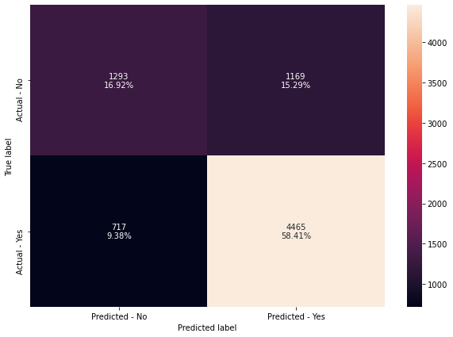

```python
make_confusion_matrix(xgb_tuned,y_test)
```

- Insights
- The accuracy is close to 75% on the test dataset
- The model is generalizing well on the dataset

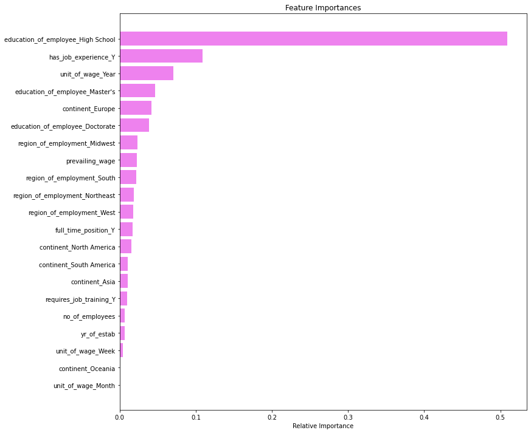

```python
importances = xgb_tuned.feature_importances_
indices = np.argsort(importances)
feature_names = list(X.columns)

plt.figure(figsize=(12,12))
plt.title('Feature Importances')
plt.barh(range(len(indices)), importances[indices], color='violet', align='center')
plt.yticks(range(len(indices)), [feature_names[i] for i in indices])
plt.xlabel('Relative Importance')
plt.show()
```

- Based off the above tuned XGB Boost classifier,the factors that are influencing the visa certification are high school education,job experience and unit of wage

## Model Performance Comparison and Conclusions

#### Comparing all models - Boosting

```python
# defining list of models
models = [abc, abc_tuned, gbc, gbc_init, gbc_tuned, xgb, xgb_tuned]

# defining empty lists to add train and test results
acc_train = []
acc_test = []
recall_train = []
recall_test = []
precision_train = []
precision_test = []

# looping through all the models to get the accuracy, precall and precision scores
for model in models:
    j = get_metrics_score(model,False)
    acc_train.append(np.round(j[0],2))
    acc_test.append(np.round(j[1],2))
    recall_train.append(np.round(j[2],2))
    recall_test.append(np.round(j[3],2))
    precision_train.append(np.round(j[4],2))
    precision_test.append(np.round(j[5],2))
```

```python
comparison_frame = pd.DataFrame({'Model':['AdaBoost with default paramters','AdaBoost Tuned',
                                          'Gradient Boosting with default parameters','Gradient Boosting with init=AdaBoost',
                                          'Gradient Boosting Tuned','XGBoost with default parameters','XGBoost Tuned'],
                                          'Train_Accuracy': acc_train,'Test_Accuracy': acc_test,
                                          'Train_Recall':recall_train,'Test_Recall':recall_test,
                                          'Train_Precision':precision_train,'Test_Precision':precision_test})
comparison_frame
```

|  | Model | Train_Accuracy | Test_Accuracy | Train_Recall | Test_Recall | Train_Precision | Test_Precision |
| --- | --- | --- | --- | --- | --- | --- | --- |
| 0 | AdaBoost with default paramters | 0.74 | 0.74 | 0.89 | 0.89 | 0.76 | 0.76 |
| 1 | AdaBoost Tuned | 0.76 | 0.75 | 0.87 | 0.86 | 0.79 | 0.79 |
| 2 | Gradient Boosting with default parameters | 0.76 | 0.75 | 0.88 | 0.87 | 0.78 | 0.79 |
| 3 | Gradient Boosting with init=AdaBoost | 0.76 | 0.75 | 0.88 | 0.87 | 0.78 | 0.79 |
| 4 | Gradient Boosting Tuned | 0.75 | 0.75 | 0.87 | 0.86 | 0.78 | 0.79 |
| 5 | XGBoost with default parameters | 0.83 | 0.74 | 0.93 | 0.86 | 0.84 | 0.78 |
| 6 | XGBoost Tuned | 0.76 | 0.75 | 0.87 | 0.86 | 0.79 | 0.79 |

### Comparing all models till now - Bagging

```python
# defining list of models
models = [bagging_estimator,bagging_estimator_tuned,bagging_lr,rf_estimator,rf_estimator_tuned,
          rf_estimator_weighted]

# defining empty lists to add train and test results
acc_train = []
acc_test = []
recall_train = []
recall_test = []
precision_train = []
precision_test = []

# looping through all the models to get the accuracy, precall and precision scores
for model in models:
    j = get_metrics_score(model,False)
    acc_train.append(np.round(j[0],2))
    acc_test.append(np.round(j[1],2))
    recall_train.append(np.round(j[2],2))
    recall_test.append(np.round(j[3],2))
    precision_train.append(np.round(j[4],2))
    precision_test.append(np.round(j[5],2))
```

```python
comparison_frame = pd.DataFrame({'Model':['Bagging classifier with default parameters','Tuned Bagging Classifier',
                                        'Bagging classifier with base_estimator=LR', 'Random Forest with deafult parameters',
                                         'Tuned Random Forest Classifier','Random Forest with class_weights'],
                                          'Train_Accuracy': acc_train,'Test_Accuracy': acc_test,
                                          'Train_Recall':recall_train,'Test_Recall':recall_test,
                                          'Train_Precision':precision_train,'Test_Precision':precision_test})
comparison_frame
```

|  | Model | Train_Accuracy | Test_Accuracy | Train_Recall | Test_Recall | Train_Precision | Test_Precision |
| --- | --- | --- | --- | --- | --- | --- | --- |
| 0 | Bagging classifier with default parameters | 0.98 | 0.70 | 0.99 | 0.77 | 0.99 | 0.78 |
| 1 | Tuned Bagging Classifier | 1.00 | 0.73 | 1.00 | 0.87 | 1.00 | 0.77 |
| 2 | Bagging classifier with base_estimator=LR | 0.74 | 0.74 | 0.88 | 0.88 | 0.76 | 0.77 |
| 3 | Random Forest with deafult parameters | 1.00 | 0.73 | 1.00 | 0.83 | 1.00 | 0.78 |
| 4 | Tuned Random Forest Classifier | 0.79 | 0.74 | 0.84 | 0.81 | 0.85 | 0.81 |
| 5 | Random Forest with class_weights | 0.79 | 0.75 | 0.87 | 0.84 | 0.83 | 0.80 |

- Insights
- Based off the above comparison,the random forest with class weights gives us the high accuracy on the test dataset. Hence this model is recommended as the ML solution for this problem. Based off this model,the top 3 drivers that significantly influence the case status are Prevailing wage,number of employees and year of establishment

## Actionable Insights and Recommendations

- Prevailing wage, number of employees and year of establishment are the top 3 important features based off bagging per the bagging ensemble technique
- Prevailing wage, number of employees, job experience, unit of wage and high school education are the emerging important features per the boosting ensemble technique
- Models are having an accuracy of close to 75% for predicting the case status
- The ML solution can be implemented by choosing random forest with class weights or XGBoost tuned
- Between both the model choices, the recommendation would be to use the XGBoost tuned as the prediction capabilities of the model is consistent on the training and test datasets